# CHIS_2009

Sean F. Larsen

May 22, 2019

```r
library(ggplot2)
library(dplyr)
```

## The California Health Interview Survey

The California Health Interview Survey (CHIS) is the nation’s largest state health survey and a critical source of data on Californians as well as on the state’s various racial and ethnic groups. Policymakers, researchers, health experts, members of the media and others depend on CHIS for credible and comprehensive data on the health of Californians.

This excersise if from the DataCamp Data Visualization with ggplot2 (Part 2) Case Study. The dataset is from the 2009 survey. The original dataset contained 47,614 observations and 536 variable. Due to the size of the original dataset and needing to be able to commit to github, the data set was reduced to the 10 variable used in the exercise and saved into the adult.csv file.

## Set-Up

This first section will read the csv file, set-up the dataframe, the rewrite the data into a new csv file adult_update.csv

```
##   RBMI BMI_P RACEHPR2 SRSEX SRAGE_P MARIT2 AB1 ASTCUR AB51 POVLL
## 1    3 28.89        6     1      32      1   1      2   -1     4
## 2    3 26.15        6     2      80      3   1      2   -1     4
## 3    3 25.06        6     1      71      1   2      1   -1     4
## 4    2 24.99        6     1      39      4   1      2   -1     4
## 5    3 25.09        6     1      75      1   2      2   -1     4
## 6    4 32.21        6     2      53      1   3      1   -1     4
```

## Exercise Code

The follwoing is the actual code from the exercise.

```r
# Explore the dataset with summary and str
summary(adult)
```

```
##       RBMI          BMI_P          RACEHPR2         SRSEX
##  Min.   :1.00   Min.   :12.65   Min.   :1.000   Min.   :1.000
##  1st Qu.:2.00   1st Qu.:22.82   1st Qu.:5.000   1st Qu.:1.000
##  Median :3.00   Median :25.74   Median :6.000   Median :2.000
##  Mean   :2.76   Mean   :26.73   Mean   :5.169   Mean   :1.592
##  3rd Qu.:3.00   3rd Qu.:29.43   3rd Qu.:6.000   3rd Qu.:2.000
##  Max.   :4.00   Max.   :93.72   Max.   :7.000   Max.   :2.000
##     SRAGE_P          MARIT2          AB1           ASTCUR
##  Min.   :18.00   Min.   :1.00   Min.   :1.00   Min.   :1.000
##  1st Qu.:44.00   1st Qu.:1.00   1st Qu.:2.00   1st Qu.:2.000
##  Median :57.00   Median :1.00   Median :2.00   Median :2.000
##  Mean   :55.67   Mean   :2.05   Mean   :2.54   Mean   :1.913
##  3rd Qu.:69.00   3rd Qu.:3.00   3rd Qu.:3.00   3rd Qu.:2.000
##  Max.   :85.00   Max.   :4.00   Max.   :5.00   Max.   :2.000
##       AB51             POVLL
##  Min.   :-1.0000   Min.   :1.000
##  1st Qu.:-1.0000   1st Qu.:2.000
##  Median :-1.0000   Median :4.000
##  Mean   :-0.7051   Mean   :3.163
##  3rd Qu.:-1.0000   3rd Qu.:4.000
##  Max.   : 3.0000   Max.   :4.000
```

```r
str(adult)
```

```
## 'data.frame':    47614 obs. of  10 variables:
##  $ RBMI    : int  3 3 3 2 3 4 2 3 2 3 ...
##  $ BMI_P   : num  28.9 26.1 25.1 25 25.1 ...
##  $ RACEHPR2: int  6 6 6 6 6 6 2 6 6 6 ...
##  $ SRSEX   : int  1 2 1 1 1 2 2 1 2 1 ...
##  $ SRAGE_P : int  32 80 71 39 75 53 67 42 33 67 ...
##  $ MARIT2  : int  1 3 1 4 1 1 1 1 1 3 ...
##  $ AB1     : int  1 1 2 1 2 3 2 2 2 1 ...
##  $ ASTCUR  : int  2 2 1 2 2 1 2 2 2 2 ...
##  $ AB51    : int  -1 -1 -1 -1 -1 -1 -1 -1 -1 -1 ...
##  $ POVLL   : int  4 4 4 4 4 4 4 4 3 4 ...
```

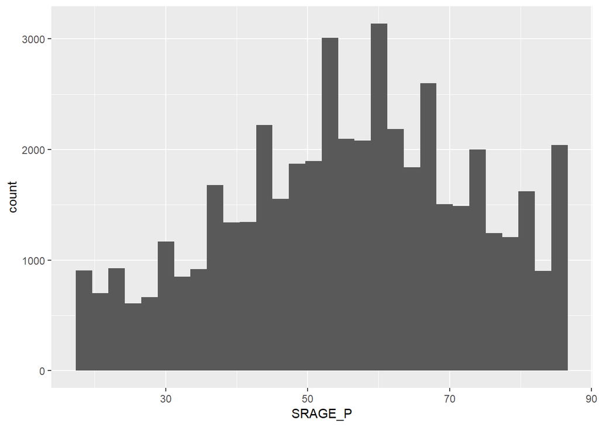

```r
# Age histogram
ggplot(adult, aes(x = SRAGE_P)) + geom_histogram()
```

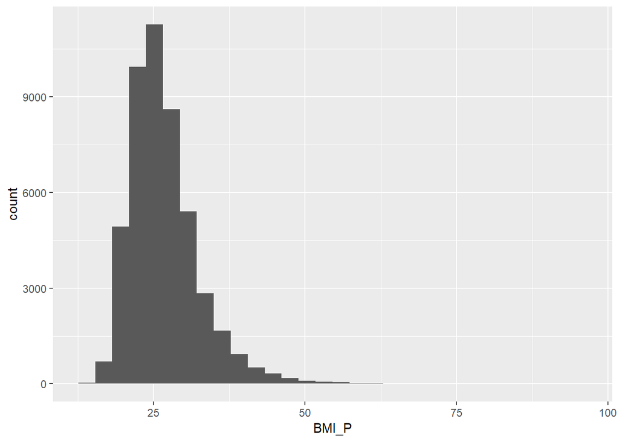

```r
# BMI value histogram
ggplot(adult, aes(x = BMI_P)) + geom_histogram()
```

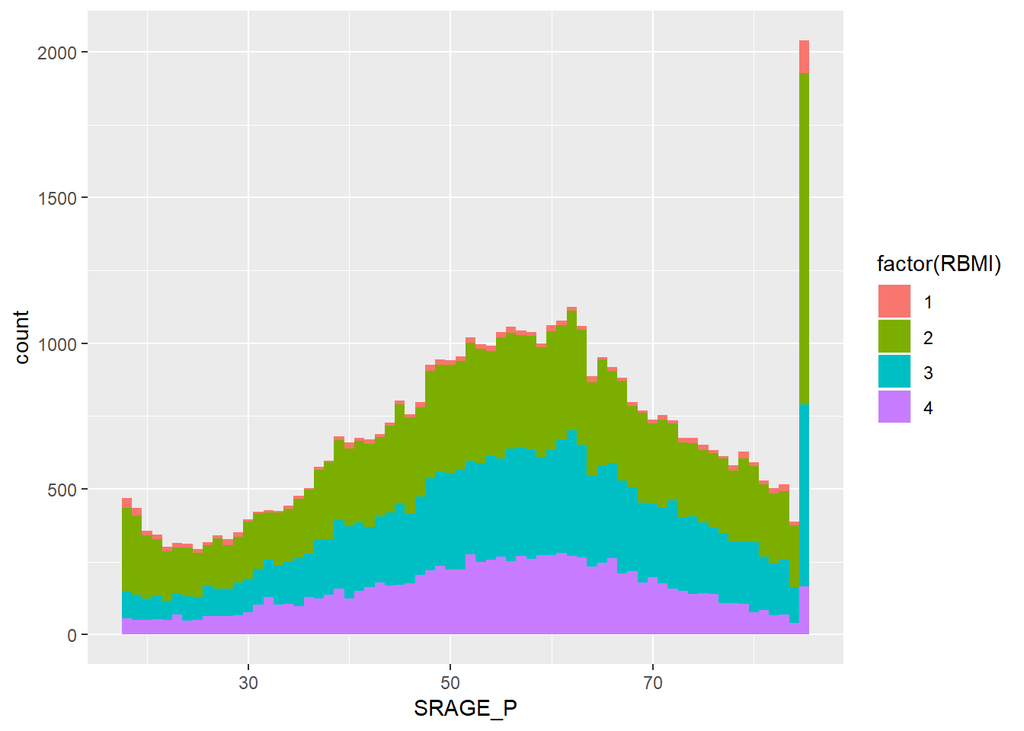

```r
# Age colored by BMI, binwidth = 1
ggplot(adult, aes(x = SRAGE_P, fill = factor(RBMI))) + geom_histogram(binwidth = 1,)
```

## Data Cleaning

```r
adult <- adult[adult$SRAGE_P <= 84, ]

# Keep adults with BMI at least 16 and less than 52
adult <- adult[adult$BMI_P >= 16 & adult$BMI_P < 52, ]

# Relabel the race variable
adult$RACEHPR2 <- factor(adult$RACEHPR2, labels = c("Latino", "Asian", "African American", "Pacific Islander", "Native American/Native Alskan", "Middle Eastern", "White"))

# Relabel the BMI categories variable
adult$RBMI <- factor(adult$RBMI, labels = c("Under-weight", "Normal-weight", "Over-weight", "Obese"))
```

## Multiple Histograms

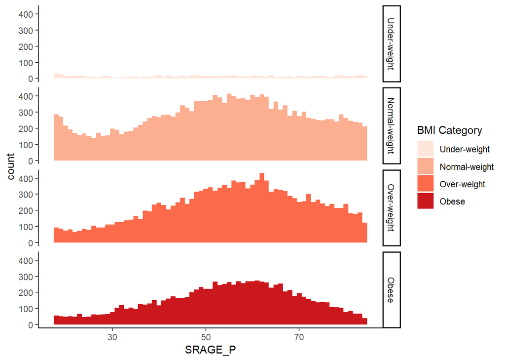

```r
# The color scale used in the plot
BMI_fill <- scale_fill_brewer("BMI Category", palette = "Reds")

# Theme to fix category display in faceted plot
fix_strips <- theme(strip.text.y = element_text(angle = 0, hjust = 0, vjust = 0.1, size = 14), strip.background = element_blank(), legend.position = "none")

# Histogram, add BMI_fill and customizations
ggplot(adult, aes (x = SRAGE_P, fill= RBMI)) + geom_histogram(binwidth = 1) + fix_strips + BMI_fill + facet_grid(RBMI ~ .) + theme_classic()
```

## Alternatives

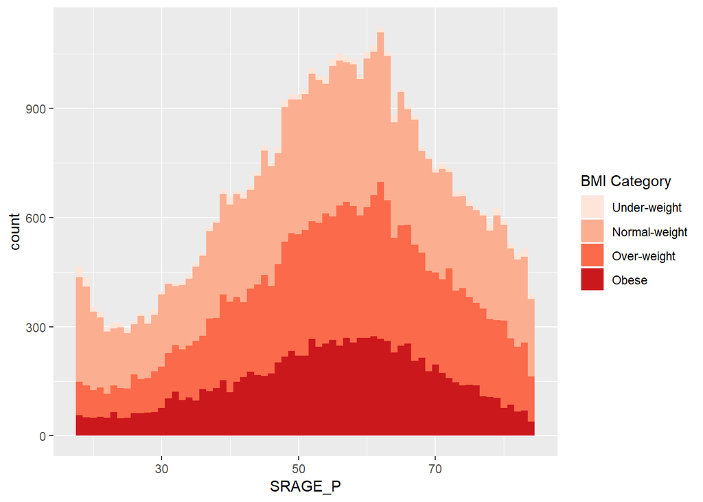

```r
# Plot 1 - Count histogram
ggplot(adult, aes (x = SRAGE_P, fill= factor(RBMI))) + geom_histogram(binwidth = 1) + BMI_fill
```

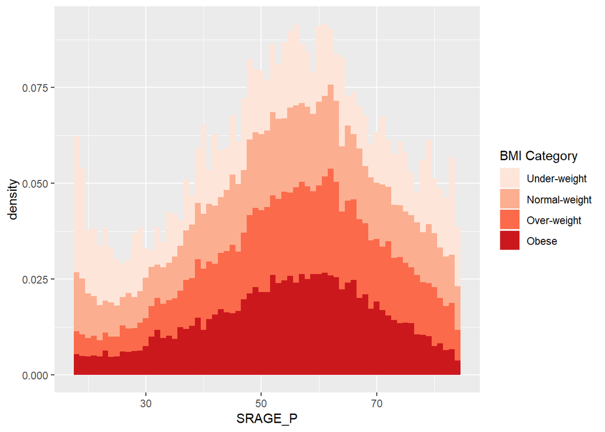

```r
# Plot 2 - Density histogram
ggplot(adult, aes (x = SRAGE_P, fill= factor(RBMI))) + geom_histogram(aes(y = ..density..), binwidth = 1) + BMI_fill
```

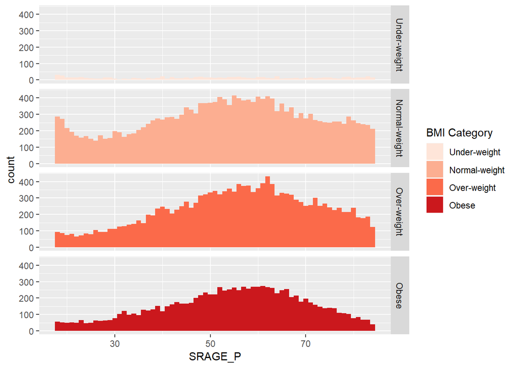

```r
# Plot 3 - Faceted count histogram
ggplot(adult, aes (x = SRAGE_P, fill= factor(RBMI))) + geom_histogram(binwidth = 1) + BMI_fill + facet_grid(RBMI ~ .)
```

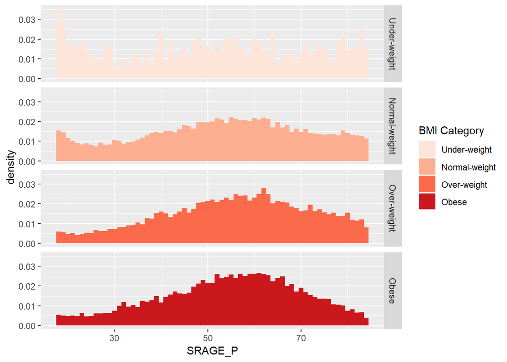

```r
# Plot 4 - Faceted density histogram
ggplot(adult, aes (x = SRAGE_P, fill= factor(RBMI))) + geom_histogram(aes(y = ..density..), binwidth = 1) + BMI_fill + facet_grid(RBMI ~ .)
```

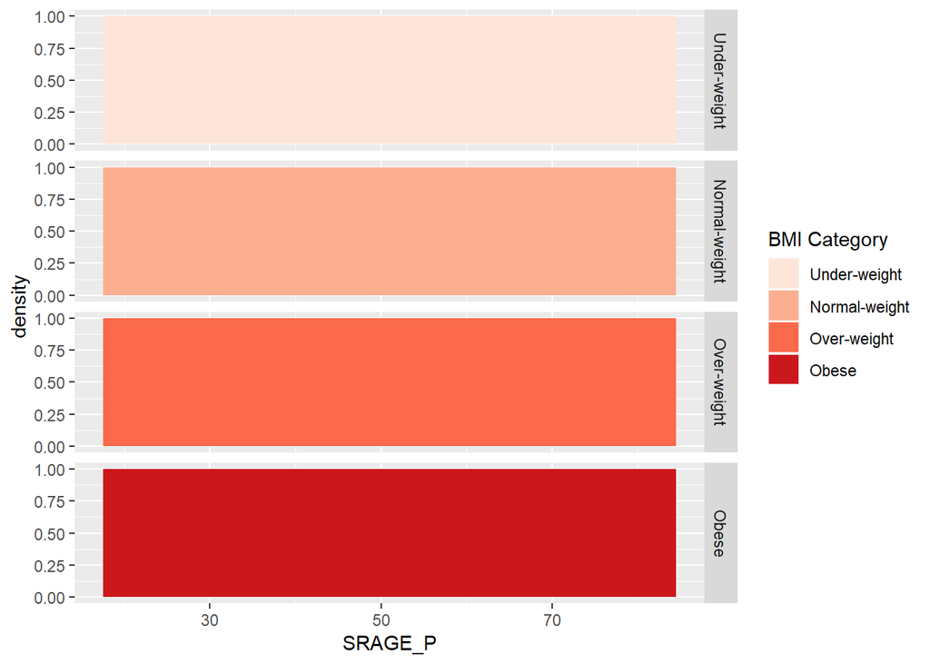

```r
# Plot 5 - Density histogram with position = "fill"
ggplot(adult, aes (x = SRAGE_P, fill= factor(RBMI))) + geom_histogram(aes(y = ..density..), binwidth = 1, position = "fill") + BMI_fill + facet_grid(RBMI ~ .)
```

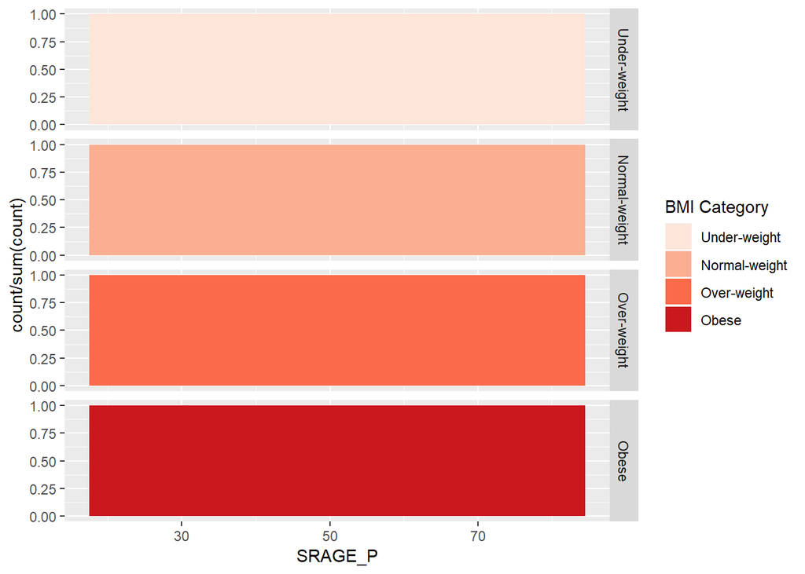

```r
# Plot 6 - The accurate histogram
ggplot(adult, aes (x = SRAGE_P, fill= factor(RBMI))) + geom_histogram(aes(y = ..count../sum(..count..)), binwidth = 1, position = "fill") + BMI_fill + facet_grid(RBMI ~ .)
```

## Do Things Manually

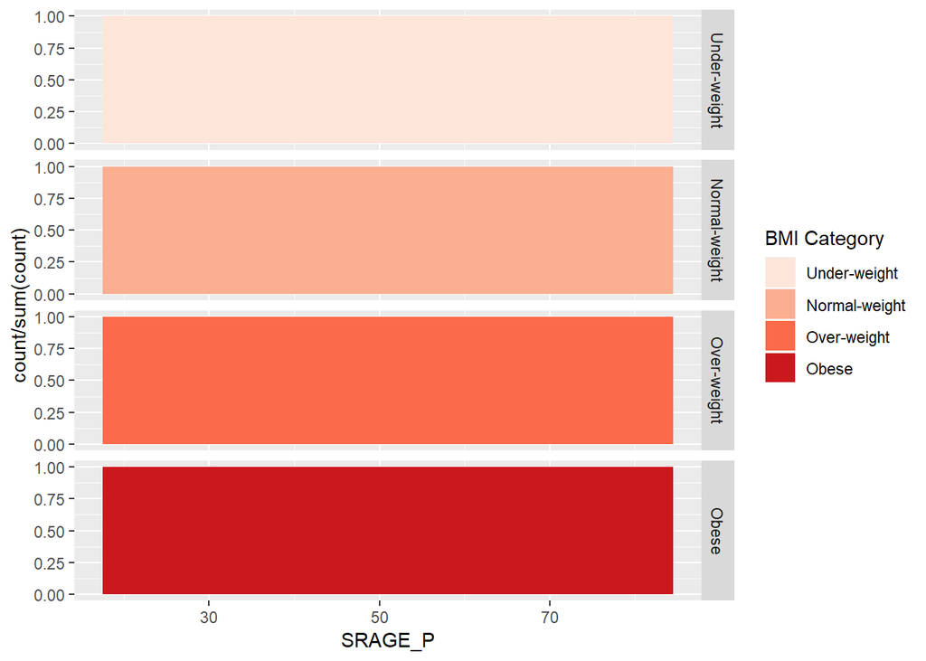

```r
# An attempt to facet the accurate frequency histogram from before (failed)
ggplot(adult, aes (x = SRAGE_P, fill= factor(RBMI))) +
  geom_histogram(aes(y = ..count../sum(..count..)), binwidth = 1, position = "fill") + BMI_fill + facet_grid(RBMI ~ .)
```

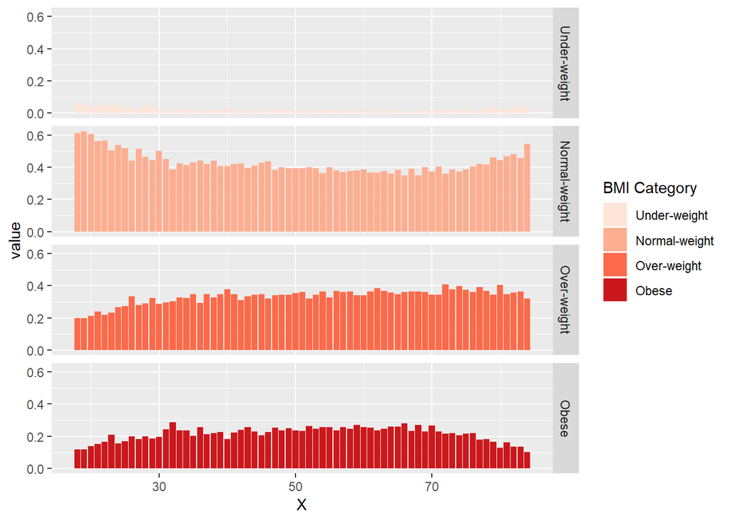

```r
# Create DF with table()
DF <- table(adult$RBMI, adult$SRAGE_P)

# Use apply on DF to get frequency of each group
DF_freq <- apply(DF, 2, function(x) x/sum(x))

# Load reshape2 and use melt on DF to create DF_melted
library(reshape2)
DF_melted <- melt(DF_freq)

# Change names of DF_melted
names(DF_melted) <- c("FILL", "X", "value")

# Add code to make this a faceted plot
ggplot(DF_melted, aes(x = X, y = value, fill = FILL)) + geom_col() + BMI_fill + facet_grid(FILL ~ .) # Facets
```

## Marimekko/Mosaic Plot

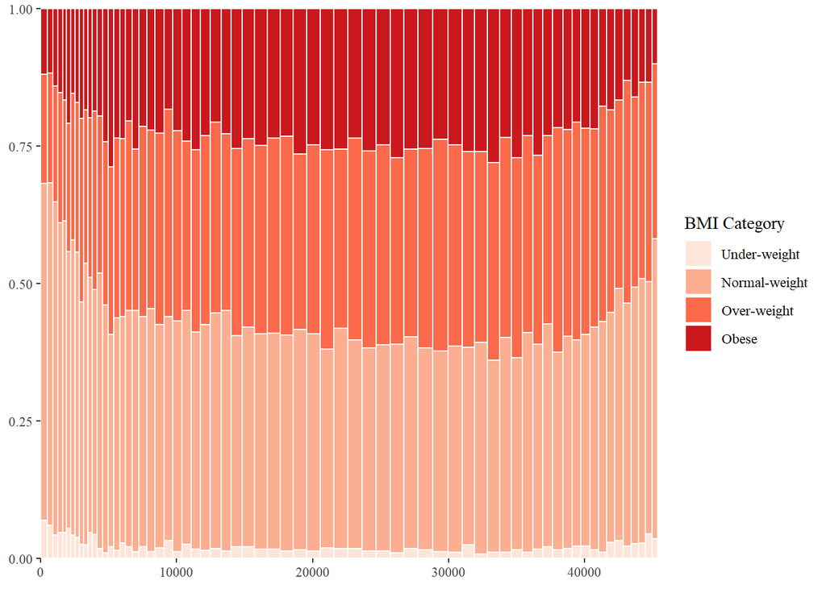

```r
# The initial contingency table
DF <- as.data.frame.matrix(table(adult$SRAGE_P, adult$RBMI))

# Create groupSum, xmax and xmin columns
DF$groupSum <- rowSums(DF)
DF$xmax <- cumsum(DF$groupSum)
DF$xmin <- DF$xmax - DF$groupSum
# The groupSum column needs to be removed; don't remove this line
DF$groupSum <- NULL

# Copy row names to variable X
DF$X <- row.names(DF)

# Melt the dataset
library(reshape2)
DF_melted <- melt(DF, id.vars = c("X", "xmin", "xmax"), variable.name = "FILL")

# dplyr call to calculate ymin and ymax - don't change
library(dplyr)
DF_melted <- DF_melted %>% group_by(X) %>% mutate(ymax = cumsum(value/sum(value)), ymin = ymax - value/sum(value))

# Plot rectangles - don't change
library(ggthemes)
ggplot(DF_melted, aes(ymin = ymin, ymax = ymax, xmin = xmin, xmax = xmax, fill = FILL)) + geom_rect(colour = "white") + scale_x_continuous(expand = c(0,0)) + scale_y_continuous(expand = c(0,0)) + BMI_fill + theme_tufte()
```

## Adding statistics

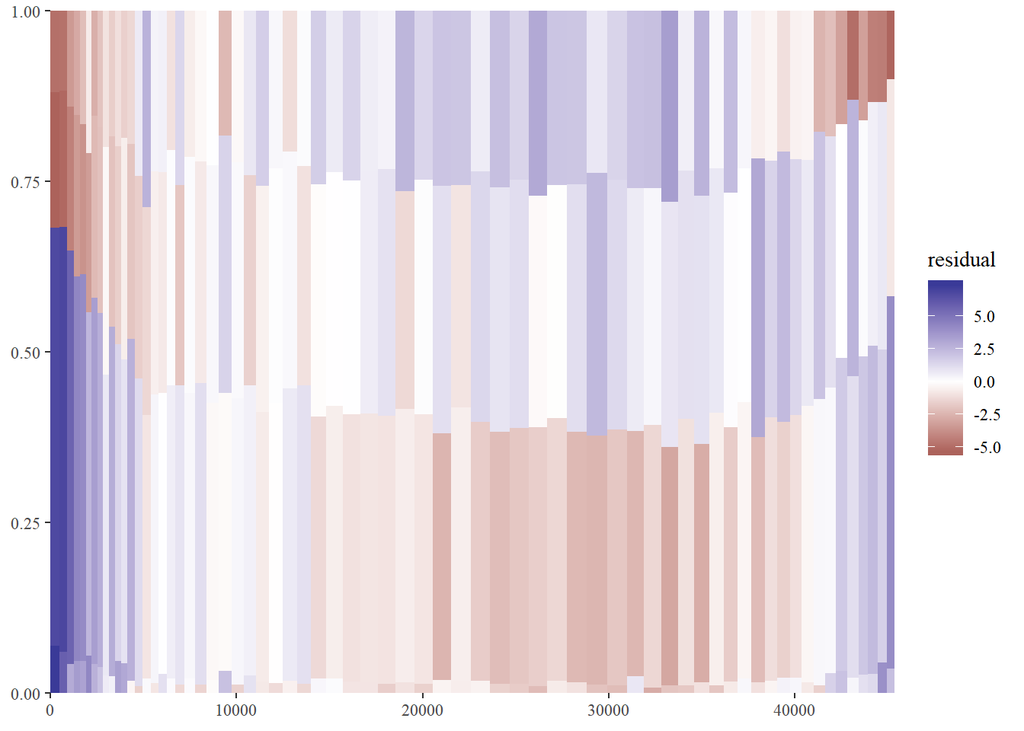

```r
# Perform chi.sq test (RBMI and SRAGE_P)
results <- chisq.test(table(adult$RBMI, adult$SRAGE_P))

# Melt results$residuals and store as resid
resid <- melt(results$residuals)

# Change names of resid
names(resid) <- c("FILL", "X", "residual")

# merge the two datasets:
DF_all <- merge(DF_melted, resid)

# Update plot command
library(ggthemes)
ggplot(DF_all, aes(ymin = ymin, ymax = ymax, xmin = xmin, xmax = xmax, fill = residual)) + geom_rect() + scale_fill_gradient2() + scale_x_continuous(expand = c(0,0)) + scale_y_continuous(expand = c(0,0)) + theme_tufte()
```

## Adding text

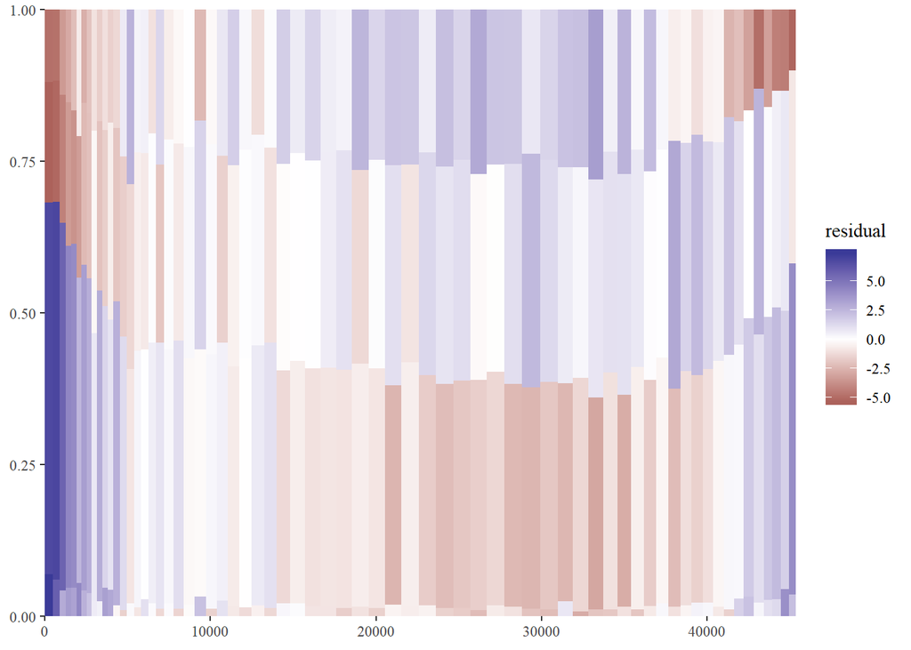

```r
# Plot so far
p <- ggplot(DF_all, aes(ymin = ymin, ymax = ymax, xmin = xmin, xmax = xmax, fill = residual)) + geom_rect() + scale_fill_gradient2() + scale_x_continuous(expand = c(0,0)) + scale_y_continuous(expand = c(0,0)) + theme_tufte()
p
```

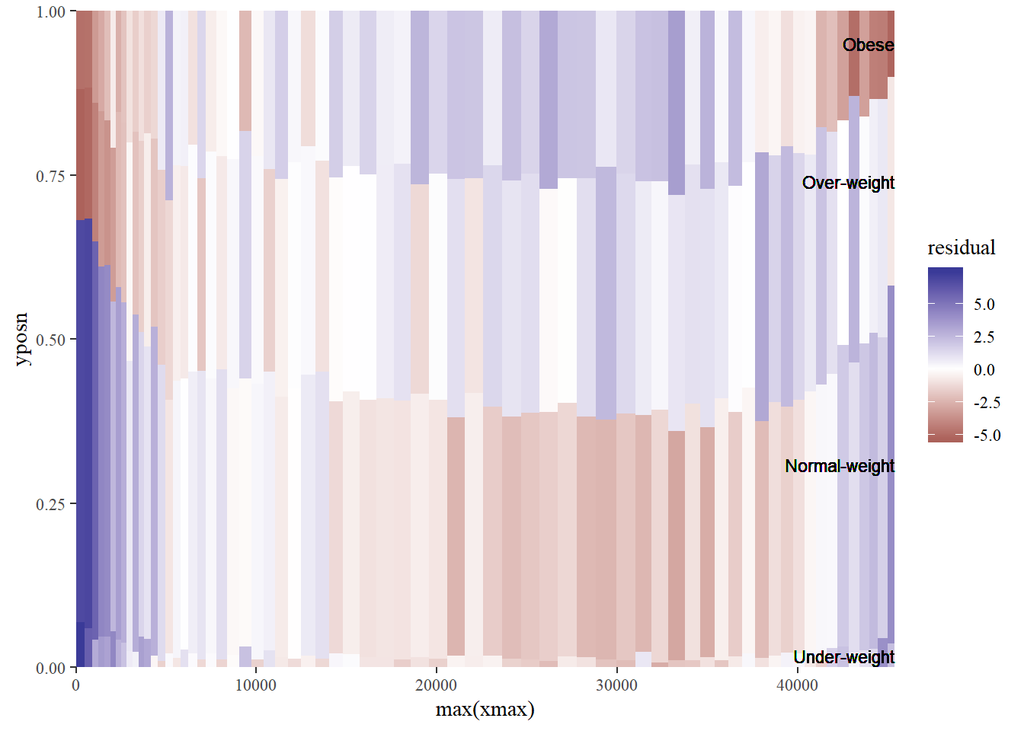

```r
# Position for labels on y axis (don't change)
index <- DF_all$xmax == max(DF_all$xmax)
DF_all$yposn <- DF_all$ymin[index] + (DF_all$ymax[index] - DF_all$ymin[index])/2

# Plot 1: geom_text for BMI (i.e. the fill axis)
p1 <- p %+% DF_all + geom_text(aes(x = max(xmax), y = yposn, label = FILL), size = 3, hjust = 1, show.legend  = FALSE)
p1
```

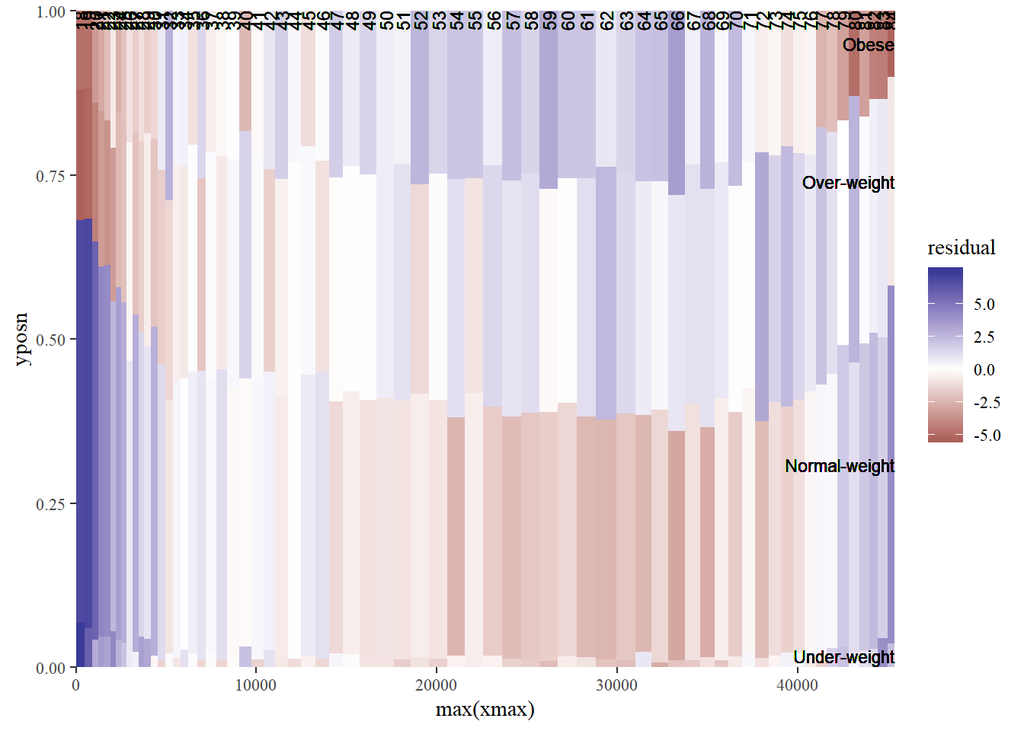

```r
# Plot 2: Position for labels on x axis
DF_all$xposn <- DF_all$xmin + (DF_all$xmax - DF_all$xmin)/2

# geom_text for ages (i.e. the x axis)
p1 %+% DF_all + geom_text(aes(x = xposn, label = X), y = 1, angle = 90, size = 3, hjust = 1, show.legend = FALSE)
```